# Chap 7.4

Mijeong Kim

```r
library(tsibble)
library(tsibbledata)
library(tibble)
library(dplyr)
library(knitr)
library(ggplot2)
library(fpp3)
library(fpp2)
library(seasonal)
library(feasts)
library(GGally)
```

## 7.4 Some useful predictors

### Trend (추세)

시계열 자료는 종종 **추세(trend)**를 가진다.  
선형 추세는 다음과 같은 회귀식으로 나타낼 수 있다:

$$y_t = \beta_0 + \beta_1 t +
\epsilon_t$$

여기서 $t=1,2,\cdots,T$ 이며, TSLM() 함수에서는 trend() 함수를 통해 추세를 포함시킬 수 있다. 비선형 추세는 7.7절에서 다룬다.

### Dummy variables

- 회귀 모형에서 예측 변수가 범주형 변수(예: “yes” / “no”)인 경우, **더미 변수(dummy variable)**를 만들어 사용할 수 있다.
- 더미 변수는 “yes”일 때 1, “no”일 때 0의 값을 가지며, **지시 변수(indicator variable)**라고도 한다.
- 예를 들어, 공휴일 여부가 매출에 영향을 미치는지 분석하고자 할 때 사용할 수 있다.
- **이상치(outlier)**가 포함된 경우, 해당 관측치만 1, 나머지는 0인 더미 변수를 추가하여 이상치의 영향을 제어할 수 있다.
- 예: 브라질 관광객 수 예측 시 2016년 리우 올림픽의 영향을 반영하기 위해 해당 연도에만 1을 주는 더미 변수 사용.
- 범주가 두 개보다 많을 경우, (범주 수 – 1)개의 더미 변수로 변환한다.
- TSLM() 함수는 factor 변수 입력 시 자동으로 더미 변수를 생성하므로, 수동으로 만들 필요는 없다.

### Seasonal dummy variables

- 요일을 예측 변수로 사용하고자 할 때, 요일별 더미 변수를 만들어 회귀식에 포함할 수 있다.
- 7개의 요일 중 6개의 더미 변수만 생성하면 되고, 나머지 하나는 **절편(intercept)**에 포함된다.
- 예: d₁,t는 Monday를 의미하고, Sunday는 모든 더미 변수가 0인 경우에 해당한다.
- **모든 요일에 대해 더미 변수를 만드는 것은 “더미 변수 함정(dummy variable trap)”**이라 하며, 다중공선성(multicollinearity)으로 인해 회귀 분석이 실패한다.
- 일반 원칙: 범주 수보다 하나 적은 개수의 더미 변수를 사용해야 한다.
  - 예: 월별 데이터는 11개, 분기별 데이터는 3개, 일별 데이터는 6개의 더미 변수만 사용한다.
- 각 더미 변수의 회귀 계수는 **제외된 기준 범주(참조 범주)**와 비교한 상대 효과를 의미한다.
  - 예: Monday의 계수는 Sunday에 비해 Monday가 미치는 효과를 나타낸다.
- TSLM() 함수에서는 season() 특수 함수를 사용하면 자동으로 요일, 월 등 계절성을 더미 변수로 처리해준다.

### Example: Australian quarterly beer production

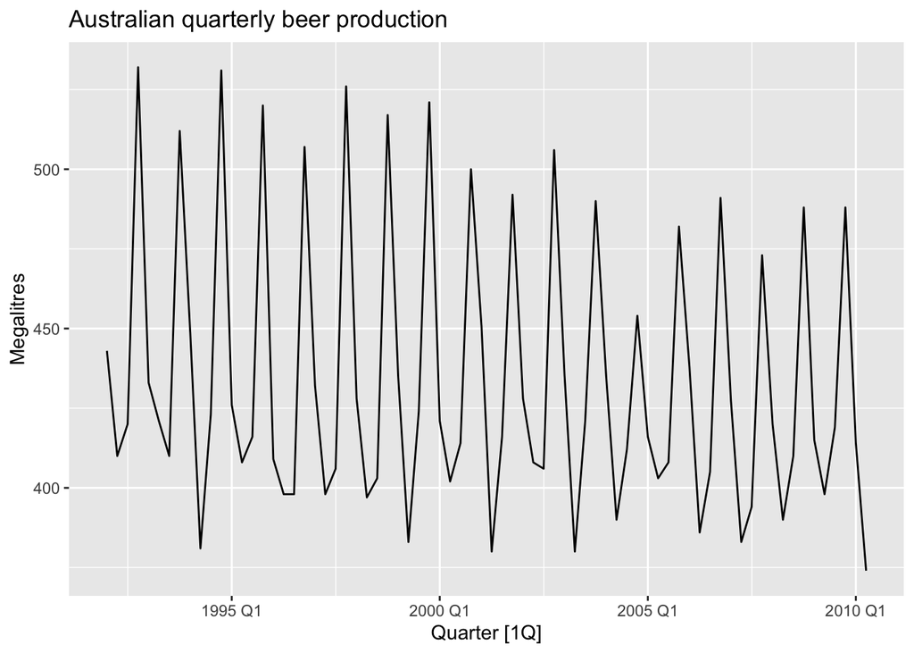

```r
recent_production <- aus_production |>
  filter(year(Quarter) >= 1992)
recent_production |>
  autoplot(Beer) +
  labs(y = "Megalitres",
       title = "Australian quarterly beer production")
```

Figure 7.14: Australian quarterly beer production.

#### 맥주 생산량 예측 회귀 모형 요약

맥주 생산량의 미래 값을 예측하기 위해 **선형 추세(linear trend)**와 **분기별 더미 변수(quarterly dummy variables)**를 포함한 회귀 모형을 사용할 수 있다.

회귀식은 다음과 같다:

$$y_t = \beta_0 + \beta_1 t + \beta_2 d_{2,t} + \beta_3 d_{3,t} + \beta_4
d_{4,t} + \varepsilon_t$$

여기서:

- $t$: 시점 (시간의 흐름)
- $d_{i,t} = 1$ if $t$는 $i$분기에 해당, 아니면 0
- $d_{1,t}$는 제외되었으며, 이는 **첫 번째 분기**가 기준 범주(reference category)로 사용되었기 때문이다.

따라서:

- $\beta_2, \beta_3, \beta_4$는 각각 **2분기, 3분기, 4분기의 효과를 1분기와 비교한 차이**를 나타낸다.

#### 참고 사항

- 이러한 구조는 `TSLM()` 함수와 `season()` 함수를 통해 자동으로 구현할 수 있다.
- 예측 시에는 `trend()`와 `season()`을 함께 사용하는 것이 유용하다.

```r
fit_beer <- recent_production |>
  model(TSLM(Beer ~ trend() + season()))
report(fit_beer)
```

```
## Series: Beer
## Model: TSLM
##
## Residuals:
##      Min       1Q   Median       3Q      Max
## -42.9029  -7.5995  -0.4594   7.9908  21.7895
##
## Coefficients:
##                Estimate Std. Error t value Pr(>|t|)
## (Intercept)   441.80044    3.73353 118.333  < 2e-16 ***
## trend()        -0.34027    0.06657  -5.111 2.73e-06 ***
## season()year2 -34.65973    3.96832  -8.734 9.10e-13 ***
## season()year3 -17.82164    4.02249  -4.430 3.45e-05 ***
## season()year4  72.79641    4.02305  18.095  < 2e-16 ***
## ---
## Signif. codes:  0 '***' 0.001 '**' 0.01 '*' 0.05 '.' 0.1 ' ' 1
##
## Residual standard error: 12.23 on 69 degrees of freedom
## Multiple R-squared: 0.9243,  Adjusted R-squared: 0.9199
## F-statistic: 210.7 on 4 and 69 DF, p-value: < 2.22e-16
```

- `trend()`와 `season()`은 일반 함수가 아니라, **`TSLM()` 모델 공식 내에서만 사용되는 특수 함수**이다.
- `trend()`는 **시간 흐름에 따른 선형 추세**를 모델링한다.
- `season()`은 **계절 효과(예: 분기, 월 등)**를 자동으로 더미 변수로 처리한다.

#### 회귀 계수 해석

맥주 생산량에 대한 회귀 결과를 요약하면 다음과 같다:

- **전반적인 추세**: 분기당 평균 **-0.34 megalitres 감소**  
  → 시간이 지날수록 생산량이 감소하는 경향이 있다.
- **2분기 효과**: 1분기 대비 **34.7 megalitres 낮다**
- **3분기 효과**: 1분기 대비 **17.8 megalitres 낮다**
- **4분기 효과**: 1분기 대비 **72.8 megalitres 높다**

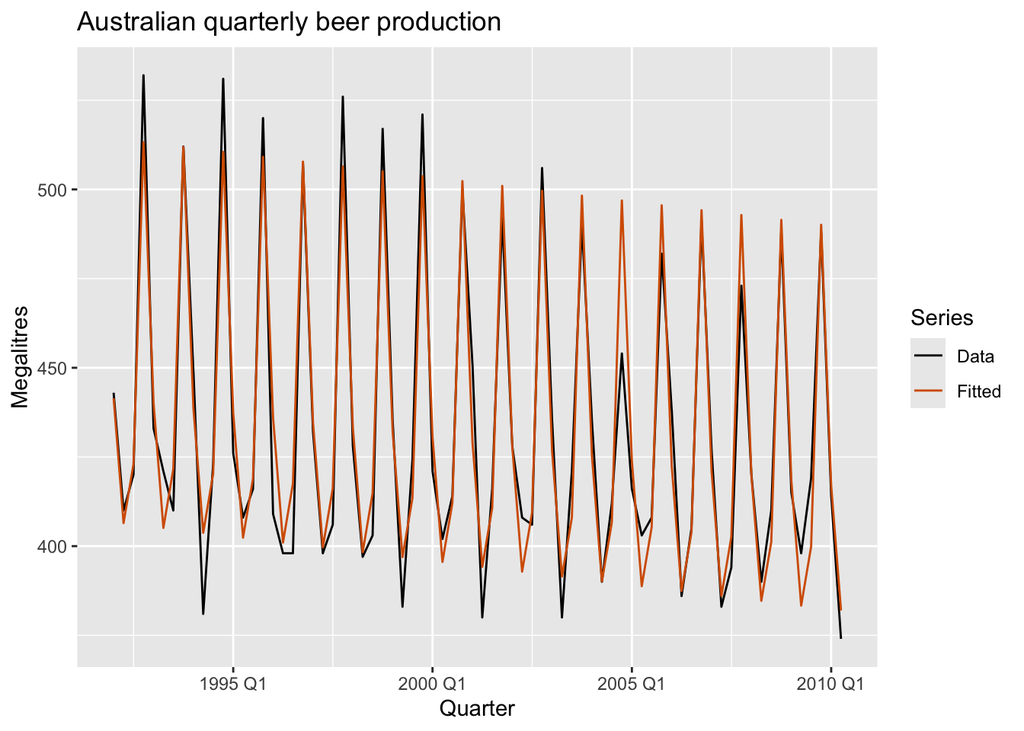

```r
augment(fit_beer) |>
  ggplot(aes(x = Quarter)) +
  geom_line(aes(y = Beer, colour = "Data")) +
  geom_line(aes(y = .fitted, colour = "Fitted")) +
  scale_colour_manual(
    values = c(Data = "black", Fitted = "#D55E00")
  ) +
  labs(y = "Megalitres",
       title = "Australian quarterly beer production") +
  guides(colour = guide_legend(title = "Series"))
```

Figure 7.15: Time plot of beer production and predicted beer production.

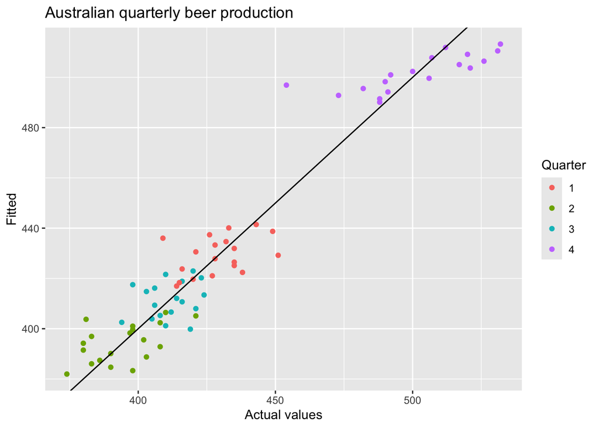

```r
augment(fit_beer) |>
  ggplot(aes(x = Beer, y = .fitted,
             colour = factor(quarter(Quarter)))) +
  geom_point() +
  labs(y = "Fitted", x = "Actual values",
       title = "Australian quarterly beer production") +
  geom_abline(intercept = 0, slope = 1) +
  guides(colour = guide_legend(title = "Quarter"))
```

Figure 7.16: Actual beer production plotted against predicted beer production.

### Intervention Variables (개입 변수)

특정 시점의 이벤트(개입)가 시계열 데이터에 영향을 미칠 경우, 이를 회귀 모형에 반영할 수 있다.

- **Spike 변수**: 효과가 **한 시점에만 나타날 때** 사용.  
  → 해당 시점에는 1, 나머지에는 0인 **더미 변수**이다. 이상치 처리를 위한 더미 변수와 동일하다.
- **Step 변수**: 개입 이후 **영구적인 수준 변화(level shift)**가 발생할 경우 사용.  
  → 개입 이전에는 0, 이후에는 1을 가지는 더미 변수이다.
- **Slope 변화**: 개입 이후 **추세의 기울기가 변할 경우**, **piecewise linear trend**를 사용한다.  
  → 이는 Section 7.7에서 다룬다.

### Trading Days (영업일 변수)

월별 영업일 수가 변동되면 매출 등 경제 변수에 영향을 준다. 이를 보정하려면:

- 해당 월의 **영업일 수**를 예측 변수로 포함시킬 수 있다.
- 또는 요일별 개수를 사용한다:  
  $x_1$ = 월요일 수, $x_2$ = 화요일 수, …, $x_7$ = 일요일 수

### Distributed Lags (시차 효과 변수)

광고비처럼 **시간이 지나도 지속 효과가 있는 변수**는 시차 변수로 포함해야 한다.

- 예측 변수로 다음을 포함할 수 있다:  
  $x_1$ = 전월 광고비,  
  $x_2$ = 2개월 전 광고비,  
  …,  
  $x_m$ = m개월 전 광고비
- 일반적으로 시차가 길어질수록 계수는 작아지는 경향이 있으나, 본 책의 범위를 벗어난다.

### Easter (이동 휴일 변수)

부활절(Easter)은 매년 날짜가 달라지므로 더미 변수로 특별 처리해야 한다.

- 월별 데이터의 경우:
  - 부활절이 3월이면 → 3월 dummy = 1
  - 4월이면 → 4월 dummy = 1
  - 부활절이 3월에 시작해 4월에 끝나면 → **비율로 나눔** (예: 0.5 / 0.5)

### Fourier Series (푸리에 계열)

**더미 변수보다 적은 수의 예측 변수로 계절성(seasonality)을 모델링**하는 대안이다.

- 푸리에 항은 sine, cosine 함수의 조합으로 구성되며, 반복되는 패턴을 표현할 수 있다.
- 계절 주기가 $m$일 때, 푸리에 항은 다음과 같다:

$$x_{1,t} = \sin\left(\frac{2\pi k t}{m}\right), \quad x_{2,t} =
\cos\left(\frac{2\pi k t}{m}\right), ~~~~~ k=1, \cdots, K$$

- 예: 월별 데이터에서 푸리에 항 11개를 사용하면 **11개 계절 더미 변수와 동일한 결과**를 얻는다.
- 주기가 긴 경우(예: 주별 데이터, $m \approx 52$)에 특히 유용하다.
- 단기 주기(예: 분기별 데이터)에서는 더미 변수가 더 간단하다.

```r
fourier_beer <- recent_production |>
  model(TSLM(Beer ~ trend() + fourier(K = 2)))
report(fourier_beer)
```

```
## Series: Beer
## Model: TSLM
##
## Residuals:
##      Min       1Q   Median       3Q      Max
## -42.9029  -7.5995  -0.4594   7.9908  21.7895
##
## Coefficients:
##                     Estimate Std. Error t value Pr(>|t|)
## (Intercept)        446.87920    2.87321 155.533  < 2e-16 ***
## trend()             -0.34027    0.06657  -5.111 2.73e-06 ***
## fourier(K = 2)C1_4   8.91082    2.01125   4.430 3.45e-05 ***
## fourier(K = 2)S1_4 -53.72807    2.01125 -26.714  < 2e-16 ***
## fourier(K = 2)C2_4 -13.98958    1.42256  -9.834 9.26e-15 ***
## ---
## Signif. codes:  0 '***' 0.001 '**' 0.01 '*' 0.05 '.' 0.1 ' ' 1
##
## Residual standard error: 12.23 on 69 degrees of freedom
## Multiple R-squared: 0.9243,  Adjusted R-squared: 0.9199
## F-statistic: 210.7 on 4 and 69 DF, p-value: < 2.22e-16
```

$$Y_t
= \beta_0
+ \beta_1 t
+ \beta_2 \sin\left(\frac{2\pi t}{m}\right)
+ \beta_3 \cos\left(\frac{2\pi t}{m}\right)
+ \beta_4 \sin\left(\frac{4\pi t}{m}\right)
+ \beta_5 \cos\left(\frac{4\pi t}{m}\right)
+ \varepsilon_t$$

#### Fourier 항과 `K` 인자 설명

`fourier()` 함수의 `K` 인자는 포함할 **sin, cos 항의 쌍의 개수**를 지정한다.

- 계절 주기 $m$에 대해, 설정 가능한 최대값은 $K = m / 2$ 이다.
- 이 **최대값으로 설정할 경우**, Fourier 항은 **계절 더미 변수**와 동일한 계절 효과를 표현할 수 있으며, 두 모형은 동일한 적합값을 산출한다.

#### 간단한 푸리에 모형

- **$K = 1$**인 경우 (즉, $x_{1,t}, x_{2,t}$만 사용), 계절 패턴은 **단순한 사인 곡선** 형태를 따른다.
- 이처럼 **푸리에 항으로 구성된 회귀 모형**을 **조화 회귀(harmonic regression)**라고 부른다.